# Multiverse Tutorial

This tutorial aims to introduce interested researchers and students to multiverse analysis. It demonstrates how to implement a multiverse analysis in R using the analysis from Authors (2021) "If you have all the choices, why not choose (and share) all of them?.

The repository can be found at: https://github.com/anonymous-researcher1899/multiverse-tutorial. This tutorial is work in progress, there you can always find the up-to-date version.

# Introduction

There are many different ways to test a given association and researchers usually only report one or a few model specifications. Model selection relies on our choices as researchers. These choices are often arbitrary and might be implicitly driven by a desire for significant results.

Given the same dataset, two researchers might choose to answer the same question in very different ways, e.g. using different variables to operationalize a latent construct, choose different functional forms, etc. [Silberzahn et al. (2018)](http://econweb.umd.edu/~pope/crowdsourcing_paper.pdf) demonstrate this problem by showing how different reserach teams come to different conclusions about the relationship between football players’ skin colour and them receiving a red card.

[Steegen et al. 2016](https://journals.sagepub.com/doi/10.1177/1745691616658637) propose to solve this problem by specifying all “reasonable” models to show how robust the findings are.

The goal of this tutorial is to help interested researchers and students getting started with multiverse analyses. We will demonstrate the implementation of the multiverse analysis using 3 different solutions: coding it from scratch by looping over the grid of options, using the R package [specr](https://cran.r-project.org/web/packages/specr/index.html), and using the R package [multiverse](https://cran.r-project.org/web/packages/specr/index.html).

# How to Do a Multiverse Analysis in R

Research question: Which content characteristics of news articles determine social media engagement with the respective article?

## The dataset

In this tutorial we will work with the dataset compiled by Authors (2021). It builds on the [useNews](https://osf.io/uzca3/) dataset, and contains information on news article content characteristics as well as the engagement metrics that news article received on Facebook once it got posted by the FB page of the respective news outlet. To speed up the process of running the multiverse of analyses, we will work with a sample of this data (n=5000) and a subset of the model specifications presented in Authors (2021).

## Define reasonable specifications

For this tutorial we use the number of times a FB post of a news article got shared as the dependent variable. As independent variables we include the sentiment of the news article, and control for the arousal, complexity, and main topic of the article. We also include some variables that are the same across all instances of the multiverse: the media outlet posting the article, the length of the article, and the year the article was posted.

The first step is to define the multiverse of analytical decisions. We therefore first list the differnt operationalizations of the included variables. Ech combination of operationalization gives rise to a differnt dataset. The sum of these datasets is the multiverse of datasets.

DV “Shares”:

- `shares_log` = logged number of shares of FB post

IV “sentiment”: We use 6 different measures of sentiment, resulting from using 3 different dictionaries (LIWC, Lexicoder, NRC) and 2 ways of combining dictionary word hits into a sentiment score (difference vs. logged ratio).

- `sentiment_liwc1` = LIWC dictionary (difference)
- `sentiment_liwc2` = LIWC dictionary (logged ratio)
- `sentiment_lsd1` = Lexicoder dictionary (difference)
- `sentiment_lsd2` = Lexicoder dictionary (logged ratio)
- `sentiment_nrc1` = NRC dictionary (difference)
- `sentiment_nrc2` = NRC dictionary (logged ratio)

Control “arousal”: We use 3 different measures of arousal, resulting from the 3 different sentiment dictionaries that were already used to construct the sentiment measure.

- `arousal_liwc1` = LIWC dictionary (sum)
- `arousal_lsd1` = Lexicoder dictionary (sum)
- `arousal_nrc1` = LSD dictionary (sum)

Control “complexity”: We use 3 different measures of textual complexity. These are rather crude measures of complexity, namely lexical diversity.

- `complexity1` = Type-Token Ratio (logged)
- `complexity2` = Carroll’s Corrected TTR (logged)
- `complexity3` = Dugast’s Uber Index (logged)

Control “topics”: This variable indicates the main topic a news article is about. There are four different topic variables, resulting from 4 different pre-processing choices of the news article DFM.

- `topics_option1` = no stemming or trimming of DFM
- `topics_option2` = trimming of DFM
- `topics_option3` = stemming of DFM
- `topics_option4` = stemming and trimming of DFM

Controls that don’t change:

- `media` = news outlet
- `tokens` = article length
- `year1` = year of FB post

Modeling:

- `OLS`: We will use one OLS model

Keep in mind that we standardize all continuous variables.

Load the dataset into the work environment and standardize variables:

```r
df = read_rds("dataset_sample.rds")

df <- df %>%
  tidylog::mutate(sentiment_liwc1 = scale(sentiment_liwc1),
                  sentiment_liwc2 = scale(sentiment_liwc2),
                  sentiment_lsd1 = scale(sentiment_lsd1),
                  sentiment_lsd2 = scale(sentiment_lsd2),
                  sentiment_nrc1 = scale(sentiment_nrc1),
                  sentiment_nrc2 = scale(sentiment_nrc2),
                  arousal_liwc1 = scale(arousal_liwc1),
                  arousal_lsd1 = scale(arousal_lsd1),
                  arousal_nrc1 = scale(arousal_nrc1),
                  complexity1 = scale(log(complexity1)),
                  complexity2 = scale(log(complexity2)),
                  complexity3 = scale(log(complexity3)),
                  arousal_liwc1 = scale(arousal_liwc1),
                  arousal_lsd1 = scale(arousal_lsd1),
                  arousal_nrc1 = scale(arousal_nrc1),
                  year = as.factor(year1),
                  media = as.factor(media),
                  length = log(ntokens))
```

## Option A: Using [specr](https://cran.r-project.org/web/packages/specr/index.html)

[specr](https://cran.r-project.org/web/packages/specr/index.html) is a fantastic package to run multiverse analyses. It is very easy to use, and comes with built in functions to visualize and inspect the results. The downside is that it currently does not handle different operatinalizations of control variables (e.g. specify to not run a model that includes different version of the same control variable). We also cannot specify control flows (e.g. everytime we use the LIWC dictionary for the measurement of sentiment, we don’t want to run models that would use the NRC option for the arousal control variable).

```r
library(specr)
```

If your analysis needs are met by the options that specr gives you, go ahead and use it! It’s the most straightforward implementation of doing a multiverse analysis in R. You can find detailed tutorials on how to use the [specr](https://cran.r-project.org/web/packages/specr/index.html) package [here](https://masurp.github.io/specr/).

[specr](https://cran.r-project.org/web/packages/specr/index.html) is very easy to use. All analysis are run with the command `run_specr`, and all you have to specify are:

- `df` = the dataset you want to use
- `y` = the dependent variable(s) to include
- `x` = the independent variable(s) to include
- `models` = the model(s) to run
- `controls` = the control variables to include

The function then does all the rest, creating datasets from the included variables and running the model(s).

```r
results_specr = specr::run_specs(df = df,
                         y = c("shares_log"),
                         x = c("sentiment_liwc1", "sentiment_liwc2",
                               "sentiment_lsd1", "sentiment_lsd2",
                               "sentiment_nrc1", "sentiment_nrc2"),
                         model = c("lm"),
                         controls = c("arousal_liwc1", "arousal_lsd1", "arousal_nrc1",
                                      "complexity1", "complexity2", "complexity3",
                                      "topics1", "topics2", "topics3", "topics4",
                                      "media", "year", "length"),
                         subsets = NULL)
```

The function returns a tibble which we can have a look at:

```r
results_specr %>% head()
```

| x | y | model | controls | estimate | std.error | statistic | p.value | conf.low | conf.high | fit_r.squared | fit_adj.r.squared | fit_sigma | fit_statistic | fit_p.value | fit_df | fit_logLik | fit_AIC | fit_BIC | fit_deviance | fit_df.residual | fit_nobs | subsets |
| --- | --- | --- | --- | --- | --- | --- | --- | --- | --- | --- | --- | --- | --- | --- | --- | --- | --- | --- | --- | --- | --- | --- |
| sentiment_liwc1 | shares_log | lm | arousal_liwc1 + arousal_lsd1 + arousal_nrc1 + complexity1 + complexity2 + complexity3 + topics1 + topics2 + topics3 + topics4 + media + year + length | -0.11430647 | 0.02441481 | -4.681849 | 0.000002919447 | -0.1621704 | -0.066442535 | 0.4604691 | 0.4515830 | 1.570387 | 51.81885 | 0 | 81 | -9309.962 | 18785.92 | 19326.85 | 12128.35 | 4918 | 5000 | all |
| sentiment_liwc2 | shares_log | lm | arousal_liwc1 + arousal_lsd1 + arousal_nrc1 + complexity1 + complexity2 + complexity3 + topics1 + topics2 + topics3 + topics4 + media + year + length | -0.11602429 | 0.02441951 | -4.751295 | 0.000002078737 | -0.1638974 | -0.068151154 | 0.4605407 | 0.4516557 | 1.570283 | 51.83377 | 0 | 81 | -9309.631 | 18785.26 | 19326.19 | 12126.74 | 4918 | 5000 | all |
| sentiment_lsd1 | shares_log | lm | arousal_liwc1 + arousal_lsd1 + arousal_nrc1 + complexity1 + complexity2 + complexity3 + topics1 + topics2 + topics3 + topics4 + media + year + length | -0.10874776 | 0.02554241 | -4.257537 | 0.000021054327 | -0.1588223 | -0.058673237 | 0.4600545 | 0.4511616 | 1.570990 | 51.73244 | 0 | 81 | -9311.882 | 18789.76 | 19330.69 | 12137.67 | 4918 | 5000 | all |
| sentiment_lsd2 | shares_log | lm | arousal_liwc1 + arousal_lsd1 + arousal_nrc1 + complexity1 + complexity2 + complexity3 + topics1 + topics2 + topics3 + topics4 + media + year + length | -0.11045098 | 0.02541201 | -4.346408 | 0.000014117728 | -0.1602699 | -0.060632087 | 0.4601382 | 0.4512466 | 1.570868 | 51.74986 | 0 | 81 | -9311.495 | 18788.99 | 19329.92 | 12135.79 | 4918 | 5000 | all |
| sentiment_nrc1 | shares_log | lm | arousal_liwc1 + arousal_lsd1 + arousal_nrc1 + complexity1 + complexity2 + complexity3 + topics1 + topics2 + topics3 + topics4 + media + year + length | -0.05686199 | 0.02543130 | -2.235906 | 0.025402642064 | -0.1067187 | -0.007005284 | 0.4586148 | 0.4496981 | 1.573083 | 51.43339 | 0 | 81 | -9318.540 | 18803.08 | 19344.01 | 12170.04 | 4918 | 5000 | all |
| sentiment_nrc2 | shares_log | lm | arousal_liwc1 + arousal_lsd1 + arousal_nrc1 + complexity1 + complexity2 + complexity3 + topics1 + topics2 + topics3 + topics4 + media + year + length | -0.05745334 | 0.02540233 | -2.261735 | 0.023757277300 | -0.1072532 | -0.007653424 | 0.4586275 | 0.4497111 | 1.573064 | 51.43603 | 0 | 81 | -9318.481 | 18802.96 | 19343.89 | 12169.75 | 4918 | 5000 | all |

Each row in this tibble contains the results from a single, including information on what dependent variable, indepenedent variable, and control variable was used. A better way to display the sum of results is to present them visually in the form of a specification curve (estimates ordered by magnitude). [specr](https://cran.r-project.org/web/packages/specr/index.html) provides a function to do just that: `plot_specs`.

[figure not shown]

```r
specr::plot_specs(results_specr, choices = c("x", "y", "controls"))
```

Whoops, we have a problem. Let’s recode one of the values of the `controls` variable in the results tibble for a nicer visual display:

```r
results_specr <- results_specr %>%
  tidylog::mutate(controls = recode(controls,
                         "arousal_liwc1 + arousal_lsd1 + arousal_nrc1 + complexity1 + complexity2 + complexity3 + topics1 + topics2 + topics3 + topics4 + media + year + length" = "all controls"))
```

Now we can display the results nicely using `plot_specs`:

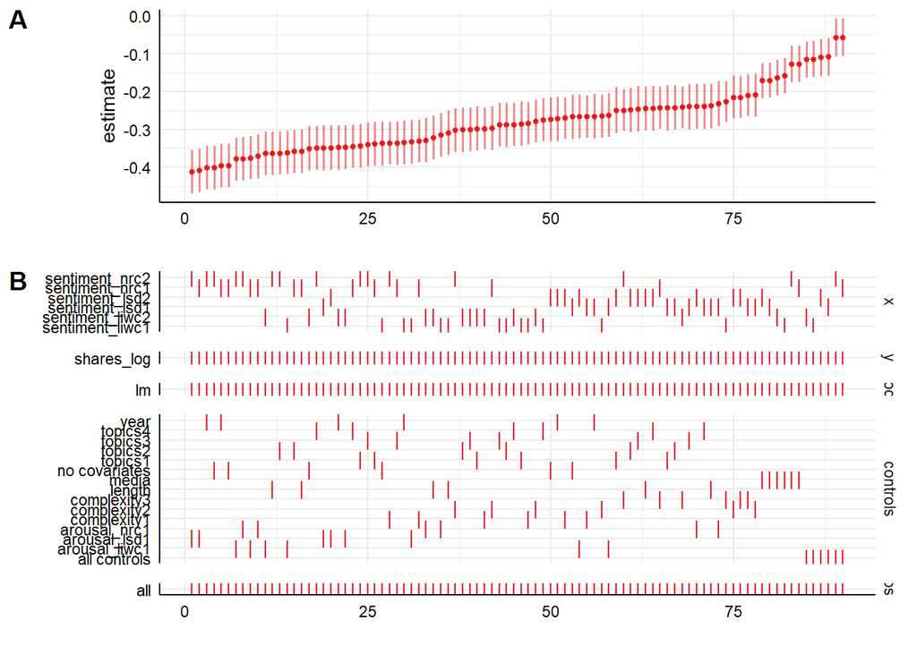

```r
specr::plot_specs(results_specr)
```

As you can see in the figure, [specr](https://cran.r-project.org/web/packages/specr/index.html), by default, includes one control variable at a time, plus a full model with all control variables. It also treats all specified controls as variables on its own, hence the final model includes all 3 measures of arousal, all 3 measures of complexity, … , in one single model.

This means that it’s a bit tricky to use [specr](https://cran.r-project.org/web/packages/specr/index.html) if you want to run models with different operationalizations of control variables, only want to include specific control variables, etc. If you need that, have a look at the next section!

## Option B: Using [multiverse](https://cran.rstudio.com/web/packages/multiverse/index.html)

The [multiverse](https://cran.rstudio.com/web/packages/multiverse/index.html) package is a more complex solution to running multiverse analyses in R. You can find the quite extensive documentation [here](https://mucollective.github.io/multiverse/).

```r
library(multiverse)
```

We use the same dataset as before, but this time we have to follow 3 steps before we are able to visualize the results

- Set up analytical data paths
- Set up model specification(s)
- Run models and extract results

### Step 1: Define analytical data paths

We use the built in dplyr-like scripting language that comes with the multiverse package. Using its `branch()` function we are able to set up analytical paths. In our example, we use the different operationalizations of `sentiment`, `arousal`, `complexity`, and `topics` as branches. The other control variables don’t change across multiverse paths, hence we only specify one option for them. Using the `%when%`-operator we can define conditions under which certain operationalizations should be used. In our example, we us this operator define that we only want to use the LIWC based arousal measure in instances where sentiment is measured with LIWC and so on.

```r
 M <- multiverse()

  # Multiverse variable options

  inside(M, {
    df <- df %>%
      mutate(Sentiment = branch(sentiment,
                                "sentiment_liwc1" ~ sentiment_liwc1,
                                "sentiment_liwc2" ~ sentiment_liwc2,
                                "sentiment_lsd1" ~ sentiment_lsd1,
                                "sentiment_lsd2" ~ sentiment_lsd2,
                                "sentiment_nrc1" ~ sentiment_nrc1,
                                "sentiment_nrc2" ~ sentiment_nrc2)
      ) %>%
      mutate(Arousal = branch(arousal,
                              "arousal_liwc1" %when%
                                (sentiment %in% c("sentiment_liwc1", "sentiment_liwc2")) ~ arousal_liwc1,
                              "arousal_lsd1" %when%
                                (sentiment %in% c("sentiment_lsd1", "sentiment_lsd2")) ~ arousal_lsd1,
                              "arousal_nrc1" %when%
                                (sentiment %in% c("sentiment_nrc1", "sentiment_nrc2")) ~ arousal_nrc1)
      ) %>%
      mutate(Complexity = branch(complexity,
                                 "complexity_option1" ~ complexity1,
                                 "complexity_option2" ~ complexity2,
                                 "complexity_option3" ~ complexity3)
      ) %>%
      mutate(Topics = branch(topics,
                             "topics_option1" ~ topics1,
                             "topics_option2" ~ topics2,
                             "topics_option3" ~ topics3,
                             "topics_option4" ~ topics4)
      ) %>%
      mutate(Year = branch(year,
                           "year_option1" ~ year1)
      ) %>%
      mutate(Length = branch(length,
                             "length_option1" ~ ntokens)
      ) %>%
      mutate(Media = branch(media,
                            "media_option1" ~ media)
      )
  })
```

### Step 2: Set up model specification(s)

```r
# Multiverse modelling options
  inside(M, {

    # M1:
    fit_m1 <- lm(
      shares_log ~ Sentiment + Arousal + Complexity +
        Topics +
        Media +
        Length,
      data = df
    )

  })

  # Multiverse model summaries
  inside(M, {
    summary_m1 <- fit_m1 %>%
      broom::tidy(conf.int = TRUE, conf.level = 0.95)

  })
```

### Step 3: Run models and extract results

We can now run all analyses using the `execute_multiverse()` function:

```r
  execute_multiverse(M)
```

Once we have run all analysis, we can extract the relevant results summary from the Multiverse object. The result is a tibble containing estimates, standard errors, etc. for all variables used in the analysis.

```r
results_multiverse <- expand(M) %>%
      tidylog::select(-.code) %>%
      mutate( summary = map(.results, "summary_m1" ) ) %>% # which summary
      unnest( cols = c(summary) ) %>%
      mutate(model = "OLS: all controls")

results_multiverse %>% head(10)
```

| .universe | sentiment | arousal | complexity | topics | year | length | media | .parameter_assignment | .results | term | estimate | std.error | statistic | p.value | conf.low | conf.high | model |
| --- | --- | --- | --- | --- | --- | --- | --- | --- | --- | --- | --- | --- | --- | --- | --- | --- | --- |
| 1 | sentiment_liwc1 | arousal_liwc1 | complexity_option1 | topics_option1 | year_option1 | length_option1 | media_option1 |  |  | (Intercept) | 3.03627418 | 0.14924825 | 20.3437841 | 0.0000000000000000000000000000000000000000000000000000000000000000000000000000000000000001997816 | 2.74368141 | 3.328866948 | OLS: all controls |
| 1 | sentiment_liwc1 | arousal_liwc1 | complexity_option1 | topics_option1 | year_option1 | length_option1 | media_option1 |  |  | Sentiment | -0.13304309 | 0.02418109 | -5.5019476 | 0.0000000394530135987488665069711224475668132072314620018005371093750000000000000000000000000000 | -0.18044875 | -0.085637428 | OLS: all controls |
| 1 | sentiment_liwc1 | arousal_liwc1 | complexity_option1 | topics_option1 | year_option1 | length_option1 | media_option1 |  |  | Arousal | -0.10463742 | 0.02516435 | -4.1581613 | 0.0000326248133190133724249558377916713425292982719838619232177734375000000000000000000000000000 | -0.15397070 | -0.055304134 | OLS: all controls |
| 1 | sentiment_liwc1 | arousal_liwc1 | complexity_option1 | topics_option1 | year_option1 | length_option1 | media_option1 |  |  | Complexity | -0.06748257 | 0.02953374 | -2.2849316 | 0.0223589707491953920692751012211374472826719284057617187500000000000000000000000000000000000000 | -0.12538179 | -0.009583344 | OLS: all controls |
| 1 | sentiment_liwc1 | arousal_liwc1 | complexity_option1 | topics_option1 | year_option1 | length_option1 | media_option1 |  |  | TopicsCRIME | 0.21776761 | 0.13739492 | 1.5849757 | 0.1130357589414112406966950175046804361045360565185546875000000000000000000000000000000000000000 | -0.05158737 | 0.487122599 | OLS: all controls |
| 1 | sentiment_liwc1 | arousal_liwc1 | complexity_option1 | topics_option1 | year_option1 | length_option1 | media_option1 |  |  | TopicsECON | 0.13557332 | 0.15374016 | 0.8818341 | 0.3779093525493310012919323526148218661546707153320312500000000000000000000000000000000000000000 | -0.16582559 | 0.436972232 | OLS: all controls |
| 1 | sentiment_liwc1 | arousal_liwc1 | complexity_option1 | topics_option1 | year_option1 | length_option1 | media_option1 |  |  | TopicsENTER | -0.81176010 | 0.14059268 | -5.7738432 | 0.0000000082210579491639130403704549543419943802291527390480041503906250000000000000000000000000 | -1.08738412 | -0.536136089 | OLS: all controls |
| 1 | sentiment_liwc1 | arousal_liwc1 | complexity_option1 | topics_option1 | year_option1 | length_option1 | media_option1 |  |  | TopicsINT | -0.15289903 | 0.13695062 | -1.1164537 | 0.2642821760045463430621737188630504533648490905761718750000000000000000000000000000000000000000 | -0.42138298 | 0.115584924 | OLS: all controls |
| 1 | sentiment_liwc1 | arousal_liwc1 | complexity_option1 | topics_option1 | year_option1 | length_option1 | media_option1 |  |  | TopicsLIFE | 0.17379286 | 0.12433540 | 1.3977745 | 0.1622434452327720100228702904132660478353500366210937500000000000000000000000000000000000000000 | -0.06995968 | 0.417545403 | OLS: all controls |
| 1 | sentiment_liwc1 | arousal_liwc1 | complexity_option1 | topics_option1 | year_option1 | length_option1 | media_option1 |  |  | TopicsPOLITICS | 0.30268625 | 0.12794004 | 2.3658445 | 0.0180273261454673601467124655073348549194633960723876953125000000000000000000000000000000000000 | 0.05186702 | 0.553505488 | OLS: all controls |

### Visualize results

We can now use this tibble to inspect the results of the multiverse analysis. However, the package does not come with built-in visualization functions, we have to do this ourselves.

Distribution of effects of sentiment:

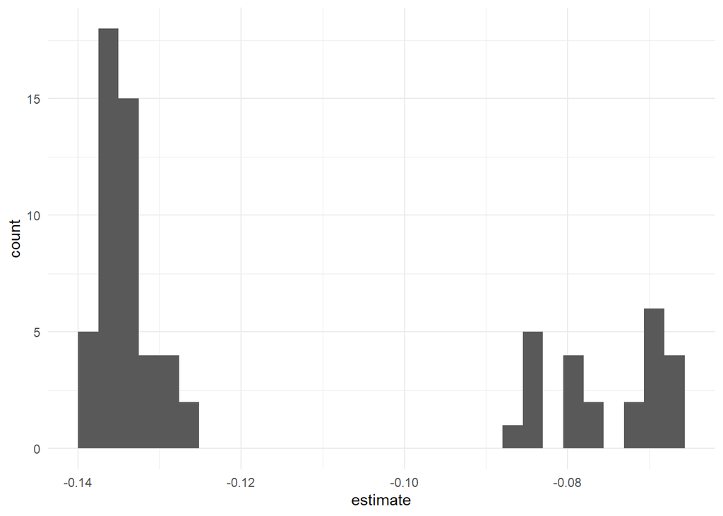

```r
results_multiverse %>%
  tidylog::filter(term == "Sentiment") %>%
  ggplot(aes(x = estimate)) +
  geom_histogram() +
  theme_minimal()
```

Distribution of p.values:

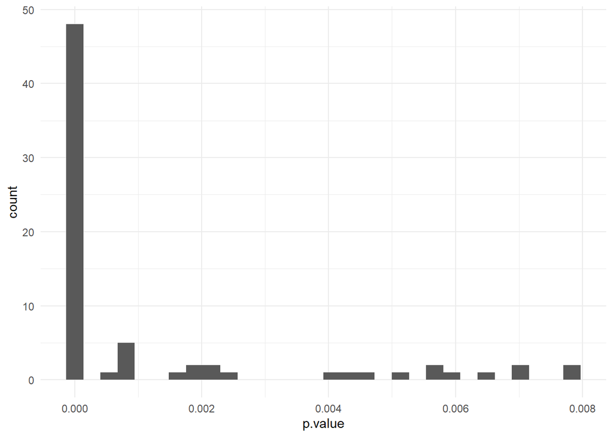

```r
results_multiverse %>%
  tidylog::filter(term == "Sentiment") %>%
  ggplot(aes(x = p.value)) +
  geom_histogram() +
  theme_minimal()
```

We can already see that across all specifications, the effect of sentiment on news sharing is negative and significant at p<0.05.

We can also recreate the specification curve from the specr package:

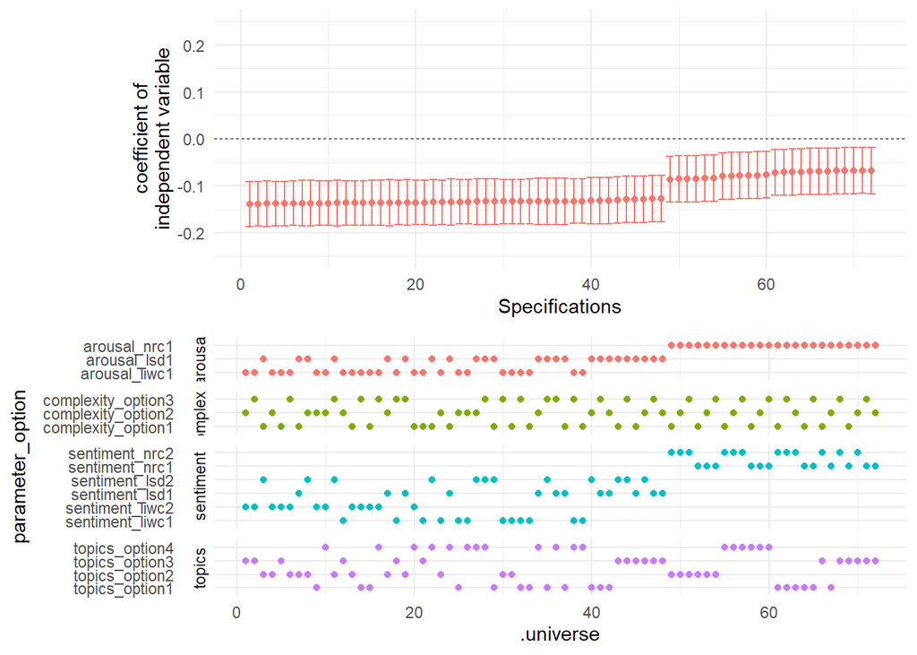

```r
choices <- c("sentiment", "arousal", "complexity", "topics")

data_curve <- results_multiverse %>%
    filter( term == "Sentiment" ) %>%
    dplyr::select( .universe, choices, estimate, p.value, conf.low, conf.high) %>%
    arrange( estimate ) %>% # sort by effect size
    mutate( .universe = 1:nrow(.))

  p1 <- data_curve %>%
    ggplot() +
    geom_point( aes(.universe, estimate, color = cut(p.value, c(0, 0.05, 1), right = FALSE))) +
    geom_errorbar(aes(.universe, ymin = conf.low, ymax = conf.high, color = cut(p.value, c(0, 0.05, 1), right = FALSE))) +
    geom_hline(yintercept = 0, size = 0.2, linetype = "dashed") +
    ylim(-0.25, 0.25) +
    labs(x = "Specifications", y = "coefficient of\nindependent variable") +
    theme_minimal() +
    theme(legend.position = "none")

  p2 <- data_curve %>%
    gather( "parameter_name", "parameter_option", choices ) %>%
    dplyr::select( .universe, parameter_name, parameter_option) %>%
    ggplot() +
    geom_point( aes(x = .universe, y = parameter_option, color = parameter_name) ) +
    facet_grid(parameter_name ~ ., space="free_y", scales="free_y", switch="y") +
    theme_minimal() +
    theme(legend.position = "none")


  cowplot::plot_grid(p1, p2, axis = "bltr",  align = "v", ncol = 1, rel_heights = c(3, 3))
```

## Option C: Coding from scratch

The last option is to code the entire multiverse anlysis from scratch by looping over different iterations of the dataset. While this is probably the easiest way of doing a multiverse analysis if one does not want to get used to a new package, our example already show how cumbersome this might get.

First, create a list for each higher level variable: `sentiment`, `arousal`, `complexity`, `topics`:

```r
sentiment <- list()
sentiment[[1]] <- df$sentiment_liwc1
sentiment[[2]] <- df$sentiment_liwc2
sentiment[[3]] <- df$sentiment_lsd1
sentiment[[4]] <- df$sentiment_lsd2
sentiment[[5]] <- df$sentiment_nrc1
sentiment[[6]] <- df$sentiment_nrc2

arousal <- list()
arousal[[1]] <- df$arousal_liwc1
arousal[[2]] <- df$arousal_lsd1
arousal[[3]] <- df$arousal_nrc

complexity <- list()
complexity[[1]] <- df$complexity1
complexity[[2]] <- df$complexity2
complexity[[3]] <- df$complexity3

topics <- list()
topics[[1]] <- df$topics1
topics[[2]] <- df$topics2
topics[[3]] <- df$topics3
topics[[4]] <- df$topics4

shares <- df$shares_log

year <- df$year
length <- df$length
media <- df$media
```

Now we can loop over each instance, create a dataset, and run a model. We also implement a control sequence to make sure that we only run models that use the same dictionary for sentiment and arousal.

```r
results <- data.frame(term = character(),
                      estimate = numeric(),
                      std.error = numeric(),
                      statistic = numeric(),
                      p.value = numeric(),
                      conf.low = numeric(),
                      conf.high = numeric())

for(i in 1:length(sentiment)){
  for(j in 1:length(complexity)){
    for(k in 1:length(topics)){

      df_model <- data.frame(shares = shares,
                             sentiment = sentiment[[i]],
                             complexity = complexity[[j]],
                             topics = topics[[k]],
                             year = year,
                             length = length,
                             media = media)

      # check which sentiment var is used and specify arousal var accordingly
      if(i %in% c(1,2)) df_model <- df_model %>% cbind(arousal = arousal[[1]])
      if(i %in% c(3,4)) df_model <- df_model %>% cbind(arousal = arousal[[2]])
      if(i %in% c(5,6)) df_model <- df_model %>% cbind(arousal = arousal[[3]])


       m <- lm(shares ~ sentiment + complexity + topics +
                 arousal + year + length + media,
               data = df_model) %>%
         broom::tidy(conf.int = TRUE, conf.level = 0.95)

       results <- results %>% rbind(m)
    }
  }
}
```

Again we can have a look at the results table for the `sentiment` variable:

```r
results %>%
  tidylog::filter(term == "sentiment") %>%
  head(10)
```

| term | estimate | std.error | statistic | p.value | conf.low | conf.high |
| --- | --- | --- | --- | --- | --- | --- |
| sentiment | -0.1320317 | 0.02418693 | -5.458803 | 0.00000005027582 | -0.1794488 | -0.08461457 |
| sentiment | -0.1321113 | 0.02432050 | -5.432099 | 0.00000005836193 | -0.1797903 | -0.08443237 |
| sentiment | -0.1334710 | 0.02420002 | -5.515327 | 0.00000003658365 | -0.1809138 | -0.08602824 |
| sentiment | -0.1308152 | 0.02431067 | -5.380977 | 0.00000007749971 | -0.1784749 | -0.08315546 |
| sentiment | -0.1319074 | 0.02418580 | -5.453921 | 0.00000005166792 | -0.1793223 | -0.08449254 |
| sentiment | -0.1319141 | 0.02431817 | -5.424509 | 0.00000006088137 | -0.1795885 | -0.08423973 |
| sentiment | -0.1333749 | 0.02419828 | -5.511752 | 0.00000003733006 | -0.1808143 | -0.08593556 |
| sentiment | -0.1306682 | 0.02430864 | -5.375380 | 0.00000007993150 | -0.1783239 | -0.08301246 |
| sentiment | -0.1321209 | 0.02417116 | -5.466056 | 0.00000004827441 | -0.1795071 | -0.08473472 |
| sentiment | -0.1321321 | 0.02429937 | -5.437675 | 0.00000005657551 | -0.1797696 | -0.08449453 |

We can of course also visualize the results using a specifiction curve. We first order the effects by magnitude and plot them:

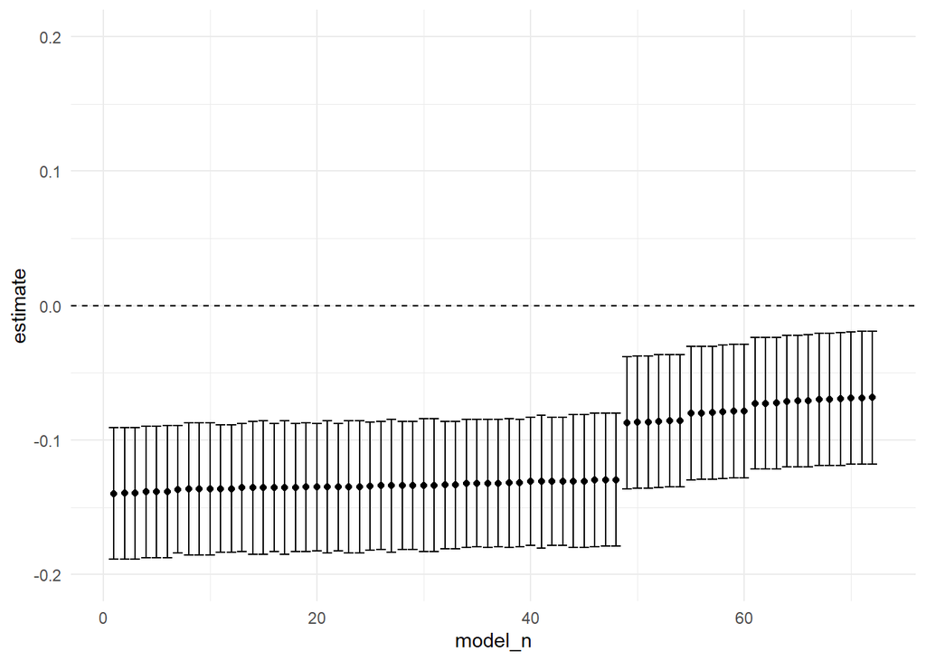

```r
plot <- results %>%
  dplyr::filter(term == "sentiment") %>%
  arrange(estimate) %>%
  mutate(model_n = 1:n()) %>% # Sort on point estimates
  ggplot(aes(x = model_n, y = estimate, ymin = conf.low, ymax = conf.high)) +
  geom_point() +
  geom_errorbar() +
  ylim(-0.2, 0.2) +
  geom_hline(yintercept = 0, linetype = "dashed") +
  theme_minimal()
plot
```